# Chapter 2: Descriptive Statistics and Variability

2026-02-25

# 1 Measures of Location

Measures of location (also called **measures of central tendency**) describe the “centre” of a dataset — a single value that best represents all observations.

## 1.1 Mean

The **mean** is the arithmetic average: sum all values, then divide by the count.

$$\bar{x} = \frac{1}{n} \sum_{i=1}^{n}
x_i$$

- Sensitive to extreme values (outliers).
- Best used when data is roughly symmetric with no outliers.

## 1.2 Median

The **median** is the middle value when data is sorted in ascending order.

- If *n* is odd → middle observation.
- If *n* is even → average of the two middle observations.
- **Robust** to outliers, making it preferable for skewed distributions.

## 1.3 Mode

The **mode** is the most frequently occurring value in the dataset.

- A dataset can have **no mode**, **one mode** (unimodal), or **multiple modes** (bimodal, multimodal).
- Especially useful for categorical data.

### 1.3.1 Quick comparison

| Measure | Sensitive to Outliers? | Best for |
| --- | --- | --- |
| Mean | Yes | Symmetric, no-outlier data |
| Median | No | Skewed data or data with outliers |
| Mode | No | Categorical data; finding most common value |

# 2 Measures of Spread

Measures of spread (also called **measures of dispersion**) describe how much the data values vary from each other and from the centre.

## 2.1 Variance

**Variance** measures the average squared distance of each data point from the mean.

$$s^2 = \frac{1}{n-1} \sum_{i=1}^{n} (x_i
- \bar{x})^2$$

The denominator uses $n - 1$ (not $n$) for sample variance — this is the **degrees of freedom correction** that makes it an unbiased estimator of the population variance $\sigma^2$.

## 2.2 Standard Deviation

**Standard deviation** is the square root of variance, bringing the units back in line with the original data.

$$s = \sqrt{s^2}$$

- Interpretable in the same units as the data (e.g., kg, °C).
- Roughly: “the typical distance of a data point from the mean.”

## 2.3 Sample vs Population Dispersion

| Formula | Symbol | When to use |
| --- | --- | --- |
| $\sigma^2 = \frac{1}{N}\sum(x_i - \mu)^2$ | Population variance | You have the *entire* population |
| $s^2 = \frac{1}{n-1}\sum(x_i - \bar{x})^2$ | Sample variance | You have a *sample* drawn from the population |

> **Key insight:** Using $n-1$ instead of $n$ corrects for the fact that a sample tends to underestimate the population spread. This correction is called **Bessel’s correction**.

# 3 Mathematical Structure

## 3.1 Variance as an Expectation

Variance can be expressed formally using the **expectation operator** $E[\cdot]$:

$$\text{Var}(X) = E\left[(X -
\mu)^2\right] = E[X^2] - (E[X])^2$$

This framing reminds us that variance is not just a formula — it is the **expected squared deviation** from the mean, a fundamental property of any random variable.

## 3.2 Degrees of Freedom and Bias

When we estimate population variance from a sample:

- We *use* the sample mean $\bar{x}$ (not the true $\mu$) to compute deviations.
- This introduces a dependency: once you know $n-1$ deviations and the mean, the last deviation is fixed.
- So only $n - 1$ deviations are **free to vary** → degrees of freedom = $n - 1$.

Using $n$ in the denominator produces a **biased** estimate (systematically too small). Using $n - 1$ removes this bias.

# 4 R Implementation

## 4.1 Built-in Functions: `mean()`, `median()`, `sd()`, `var()`

```r
# Dataset with a clear outlier
data <- c(10, 20, 30, 40, 100)

mean(data)     # arithmetic average — pulled up by the outlier
```

```
#> [1] 40
```

```r
median(data)   # middle value — unaffected by the outlier
```

```
#> [1] 30
```

```r
sd(data)       # standard deviation
```

```
#> [1] 35.35534
```

```r
var(data)      # variance (sd squared)
```

```
#> [1] 1250
```

Notice how the **mean (40)** is much higher than the **median (30)** because of the outlier `100`. The median gives a better sense of the “typical” value here.

## 4.2 Implementing Estimators from Definitions

Building estimators by hand deepens understanding and is useful for custom measures not covered by built-in functions.

```r
data <- c(10, 20, 30, 40, 100)
n    <- length(data)

# --- Sample mean (from definition) ---
mean_manual <- sum(data) / n
mean_manual
```

```
#> [1] 40
```

```r
# --- Sample variance (from definition, using n-1) ---
deviations       <- data - mean_manual        # xi - x̄
squared_devs     <- deviations^2              # (xi - x̄)²
variance_manual  <- sum(squared_devs) / (n - 1)
variance_manual
```

```
#> [1] 1250
```

```r
# Verify against built-in
all.equal(mean_manual,     mean(data))
```

```
#> [1] TRUE
```

```r
all.equal(variance_manual, var(data))
```

```
#> [1] TRUE
```

## 4.3 Robustness and Outlier Analysis

**Robustness** refers to how resistant a statistic is to extreme values. A statistic is *robust* if a small number of outliers cannot change it dramatically.

```r
# Two datasets: one clean, one with an extreme outlier
clean   <- c(10, 20, 30, 40, 50)
outlier <- c(10, 20, 30, 40, 1000)

# Compare how mean and median react
cat("Mean  — clean:", mean(clean),   " | with outlier:", mean(outlier),   "\n")
```

```
#> Mean  — clean: 30  | with outlier: 220
```

```r
cat("Median— clean:", median(clean), " | with outlier:", median(outlier), "\n")
```

```
#> Median— clean: 30  | with outlier: 30
```

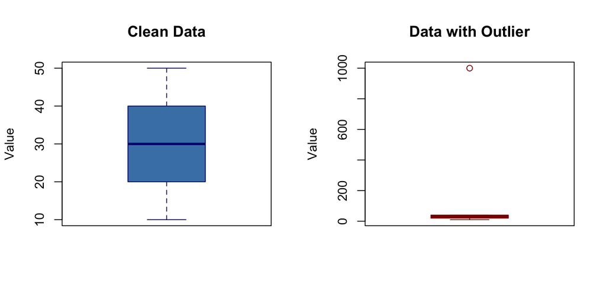

```r
par(mfrow = c(1, 2))

boxplot(clean,
        main   = "Clean Data",
        ylab   = "Value",
        col    = "steelblue",
        border = "navy")

boxplot(outlier,
        main   = "Data with Outlier",
        ylab   = "Value",
        col    = "lightcoral",
        border = "darkred")
```

```r
par(mfrow = c(1, 1))
```

> **Rule of thumb:** If `mean` and `median` differ substantially, suspect skewness or outliers. Always pair numerical summaries with a boxplot or histogram.

# 5 Chapter Summary

| Concept | Key Takeaway |
| --- | --- |
| Mean | Average; sensitive to outliers |
| Median | Middle value; robust to outliers |
| Mode | Most frequent value; useful for categorical data |
| Variance $s^2$ | Average squared deviation from the mean |
| Standard Deviation $s$ | Typical distance from the mean; same units as data |
| Population vs Sample | Use $N$ for populations; use $n-1$ (Bessel’s correction) for samples |
| Degrees of Freedom | Number of values free to vary = $n - 1$ |
| Robustness | Median and IQR are robust; mean and SD are not |
| R functions | `mean()`, `median()`, `sd()`, `var()` |